# Example 1

## Example

Make a sine wave which at 44100 Hz sampling rate has a frequency of 400 Hz at 1 second duration.

Hence we need 44100 samples, and 400 periods of our sinusoid in this second. Hence we can write our signal in python as:

```python
%matplotlib inline
import numpy as np
from sound import *
import matplotlib.pyplot as plt

fs = 44100
f = 400
s = np.sin(2 * np.pi * f *np.arange(0, 1., 1./fs))
```

Listen to it:

```python
sound(s*2**15, fs)
```

```
* done
```

Now plot the first 1000 samples:

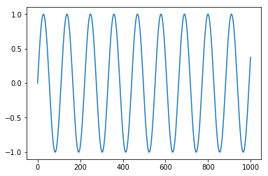

```python
plt.plot(s[:1000])
```

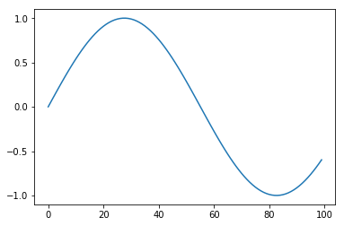

```python
plt.plot(s[:100])
```

Now we can multiply this sine tone signal with a unit pulse train, with N=8.  
We use an indexing trick to get the desired result of only keeping every 8th sample and having zeros in between:

```python
sdu = np.zeros(s.shape)
sdu[::8] = s[::8]
```

Now plot the result, the first 100 samples:

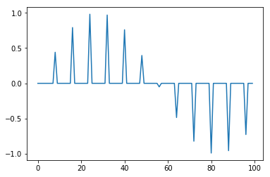

```python
plt.plot(sdu[:100])
```

Now take a look at the spectrum of the original signal s:

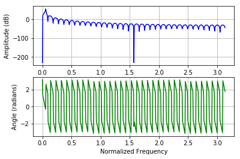

```python
from freqz import *
freqz(s)
```

Now we can compare this to our signal with the zeros, sdu:

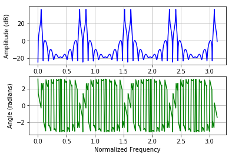

```python
freqz(sdu)
```

Here we can see the original line of our 400 Hz tone, and now also the 7 new aliasing components. Observe that always 2 aliasing components are close together. This is because the original 400 Hz tone also has a spectral peak at the negative frequencies, at -400 Hz, or rather -0.018...

Now also listen to the signal with the zeros:

```python
sound(sdu*2**15, 44100)
```

```
* done
```

Here you can hear that it sounds quite different from the original, because of the string of aliasing components!

### Removing the zeros

The final step of downsampling is now to omit the zeros between the samples, to obtain the **lower sampling rate**. Let's call the signal without the zeros $y(m)$, where the time index $m$ denotes the lower sampling rate (as opposed to $n$ , which denotes the higher sampling rate).

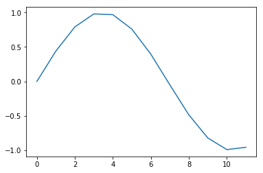

```python
sd = np.zeros(sdu.shape[0]/8)
sd = sdu[::8]
plt.plot(sd[:100/8])
```

Observe that here we only have $100/8 \approx 12$ samples left.